# Live Demo of R and Data Use Cases

Nick Mader (nmader@chapinhall.org)

TCOM Conference – November 18, 2016

# Data Management

## Read Data

R can read from–and write to–just about any data format, allowing users of many different types of software to work together.

```r
library(readxl)
d <- read_excel(path = "Dummy CANS Data.xlsx", sheet = 1)
df <- as.data.frame(d)
```

## Examine Data

```r
# The str() function examines the structure of data
# (The "#" at the beginning of a line of code creates a "comment",
#  i.e. plain English that we can use to describe the rationale for
#  the steps that we take.)
str(df)
```

```
## 'data.frame':    4031 obs. of  96 variables:
##  $ MEDICAID_ID                       : num  1e+08 1e+08 1e+08 1e+08 1e+08 ...
##  $ youthID                           : num  5648 5646 5644 5644 5643 ...
##  $ Region                            : num  100 100 100 100 100 100 100 100 100 100 ...
##  $ age                               : num  11 13 10 10 16 8 6 8 12 6 ...
##  $ gender                            : chr  "Female" "Female" "Male" "Male" ...
##  $ culturalgroup                     : num  2 2 1 1 2 1 2 2 2 7 ...
##  $ primary_language_code             : num  NA 1 1 1 5 1 5 5 2 1 ...
##  $ episode                           : num  1 1 1 1 1 1 1 3 1 1 ...
##  $ DaystoAssess                      : num  20 43 27 116 41 28 15 21 41 10 ...
##  $ typeofassess                      : chr  "CANS  5to18 Initial Assessment" "CANS  5to18 Initial Assessment" "CANS  5to18 Initial Assessment" "CANS  5to18 Closing Summary" ...
##  $ programIDNum                      : num  125 147 20 20 159 20 133 171 147 133 ...
##  $ clinicianIDNum                    : num  511 749 284 284 749 261 747 51 749 747 ...
##  $ AssessUniq                        : num  18626 11378 17797 17796 12444 ...
##  $ Data_Entry_Time                   : POSIXct, format: "1899-12-30 13:18:00" "1899-12-30 17:16:00" ...
```

[output cut: 82 more lines]

## Filter Data

Given the size of the data, let’s first pick a subset of rows and columns to focus on to have a simple set of output to work with for our demo. The code below selects rows which correspond to initial assessments, and select columns for youth ID, age, number of episode, and any column that starts with “risk”.

After subsetting, we can use the function `dim()` to print information about the number of rows and columns in the data.

```r
sub <- subset(df,
              subset = typeofassess == "CANS  5to18 Initial Assessment",
              select = c("youthID", "age", "episode", "gender", grep("^risk", colnames(d), value = TRUE)))
dim(sub)
```

```
## [1] 2049   13
```

We might start examining the data by using the `head()` function to examine the first several cases at the top of a data set. (Unsurprisingly, the `tail()` function shows a handful of cases at the bottom!)

```r
head(sub)
```

```
##   youthID age episode gender risk_suicide_risk risk_other_self_harm
## 1    5648  11       1 Female                 0                    0
## 2    5646  13       1 Female                 1                    0
## 3    5644  10       1   Male                 0                    0
## 5    5643  16       1 Female                 0                    0
## 6    5642   8       1 Female                 0                    0
## 7    5641   6       1   Male                 0                    0
##   risk_danger_to_others risk_sexual_aggression risk_runaway
## 1                     0                      0            0
## 2                     0                      0            0
## 3                     0                      0            0
## 5                     0                      0            0
## 6                     0                      0            0
## 7                     0                      0            0
##   risk_delinquency risk_fire_setting risk_social_behavior
## 1                0                 0                    0
## 2                0                 0                    1
## 3                0                 0                    0
## 5                0                 0                    0
## 6                0                 0                    0
## 7                0                 0                    0
##   risk_sexually_reactive
## 1                      0
## 2                      0
## 3                      0
## 5                      0
## 6                      0
## 7                      0
```

Now we can continue to examine the data set by getting a summary of column values. The `summary()` function smartly summarizes the data in each column, based on the type of information it contains.

```r
summary(sub)
```

```
##     youthID          age           episode          gender
##  Min.   :   1   Min.   : 5.00   Min.   : 1.000   Length:2049
##  1st Qu.:1605   1st Qu.: 9.00   1st Qu.: 1.000   Class :character
##  Median :3335   Median :13.00   Median : 2.000   Mode  :character
##  Mean   :3081   Mean   :12.53   Mean   : 3.875
##  3rd Qu.:4513   3rd Qu.:16.00   3rd Qu.: 5.000
##  Max.   :5648   Max.   :22.00   Max.   :37.000
##  risk_suicide_risk risk_other_self_harm risk_danger_to_others
##  Min.   :0.0000    Min.   :0.0000       Min.   :0.0000
##  1st Qu.:0.0000    1st Qu.:0.0000       1st Qu.:0.0000
##  Median :0.0000    Median :0.0000       Median :0.0000
##  Mean   :0.2352    Mean   :0.2094       Mean   :0.5598
##  3rd Qu.:0.0000    3rd Qu.:0.0000       3rd Qu.:1.0000
##  Max.   :3.0000    Max.   :3.0000       Max.   :3.0000
##  risk_sexual_aggression  risk_runaway    risk_delinquency
##  Min.   :0.00000        Min.   :0.0000   Min.   :0.0000
##  1st Qu.:0.00000        1st Qu.:0.0000   1st Qu.:0.0000
##  Median :0.00000        Median :0.0000   Median :0.0000
##  Mean   :0.04929        Mean   :0.2528   Mean   :0.2977
##  3rd Qu.:0.00000        3rd Qu.:0.0000   3rd Qu.:0.0000
##  Max.   :3.00000        Max.   :3.0000   Max.   :3.0000
##  risk_fire_setting risk_social_behavior risk_sexually_reactive
##  Min.   :0.00000   Min.   :0.0000       Min.   :0.00000
##  1st Qu.:0.00000   1st Qu.:0.0000       1st Qu.:0.00000
##  Median :0.00000   Median :0.0000       Median :0.00000
##  Mean   :0.03465   Mean   :0.5847       Mean   :0.09907
##  3rd Qu.:0.00000   3rd Qu.:1.0000       3rd Qu.:0.00000
##  Max.   :3.00000   Max.   :3.0000       Max.   :3.00000
```

We see that the `gender` column is listed as being stored as a “character”. We can change that to a “`factor`” data type to reflect the fact that we expect only certain set of values, and want to prevent other values from getting written into that column

A column’s address is given as `<data table>$<column name>` and assignments can be made using the left arrow `<-`.

```r
sub$gender <- factor(sub$gender)
summary(sub)
```

```
##     youthID          age           episode          gender
##  Min.   :   1   Min.   : 5.00   Min.   : 1.000   Female: 790
##  1st Qu.:1605   1st Qu.: 9.00   1st Qu.: 1.000   Male  :1257
##  Median :3335   Median :13.00   Median : 2.000   Other :   2
##  Mean   :3081   Mean   :12.53   Mean   : 3.875
##  3rd Qu.:4513   3rd Qu.:16.00   3rd Qu.: 5.000
##  Max.   :5648   Max.   :22.00   Max.   :37.000
##  risk_suicide_risk risk_other_self_harm risk_danger_to_others
##  Min.   :0.0000    Min.   :0.0000       Min.   :0.0000
##  1st Qu.:0.0000    1st Qu.:0.0000       1st Qu.:0.0000
##  Median :0.0000    Median :0.0000       Median :0.0000
##  Mean   :0.2352    Mean   :0.2094       Mean   :0.5598
##  3rd Qu.:0.0000    3rd Qu.:0.0000       3rd Qu.:1.0000
##  Max.   :3.0000    Max.   :3.0000       Max.   :3.0000
##  risk_sexual_aggression  risk_runaway    risk_delinquency
##  Min.   :0.00000        Min.   :0.0000   Min.   :0.0000
##  1st Qu.:0.00000        1st Qu.:0.0000   1st Qu.:0.0000
##  Median :0.00000        Median :0.0000   Median :0.0000
##  Mean   :0.04929        Mean   :0.2528   Mean   :0.2977
##  3rd Qu.:0.00000        3rd Qu.:0.0000   3rd Qu.:0.0000
##  Max.   :3.00000        Max.   :3.0000   Max.   :3.0000
##  risk_fire_setting risk_social_behavior risk_sexually_reactive
##  Min.   :0.00000   Min.   :0.0000       Min.   :0.00000
##  1st Qu.:0.00000   1st Qu.:0.0000       1st Qu.:0.00000
##  Median :0.00000   Median :0.0000       Median :0.00000
##  Mean   :0.03465   Mean   :0.5847       Mean   :0.09907
##  3rd Qu.:0.00000   3rd Qu.:1.0000       3rd Qu.:0.00000
##  Max.   :3.00000   Max.   :3.0000       Max.   :3.00000
```

We can see that R is now smartly treating the `gender` column as categorical and gives us a more helpful summary.

## Reshape Data

In a [great article](https://www.jstatsoft.org/article/view/v059i10), Hadley Wickham (hero developer of R) describes the value of creating “tidy” datasets. In brief, he recommends creating data tables where each row corresponds to the fundamental until of analysis, and all relevant contextual information is stored in columns.

We use the `reshape2` package to reshape our data. As input, we tell the `melt()` function (which converts data to “long” format) which data set we want to melt (i.e. `sub` instead of `df`) and which variables define the “id” columns we want to preserve.

```r
library(reshape2)
sub_long <- melt(sub,
                 id.vars = c("youthID", "age", "episode", "gender"))
head(sub_long)
```

```
##   youthID age episode gender          variable value
## 1    5648  11       1 Female risk_suicide_risk     0
## 2    5646  13       1 Female risk_suicide_risk     1
## 3    5644  10       1   Male risk_suicide_risk     0
## 4    5643  16       1 Female risk_suicide_risk     0
## 5    5642   8       1 Female risk_suicide_risk     0
## 6    5641   6       1   Male risk_suicide_risk     0
```

```r
dim(sub_long)
```

```
## [1] 18441     6
```

Here, we can confirm that there’s a new structure, and can see that our data did get much longer.

## Create Classifications

Let’s create a new column that indicates whether an item is actionable.

```r
sub_long$actionable <- sub_long$value >= 2
summary(sub_long$actionable)
```

```
##    Mode   FALSE    TRUE    NA's
## logical   17195    1246       0
```

Rather than store the values as “logical” TRUE/FALSE values, we can also convert the values to be numeric, i.e. 1 vs 0.

```r
sub_long$actionable <- as.numeric(sub_long$actionable)
mean(sub_long$actionable)
```

```
## [1] 0.06756683
```

A 1 vs 0 format is handier when, for instance, we can take the `mean()` of that column to obtain the percentage of scored items that were a value of 1.

When generating reports, we can also embed R expressions in plain English. For example, the calculated percentage of items that are actionable is 6.8%. (But you’d have to look at the .Rmd file to see how this number was embedded!)

# Data Analysis

## Descriptive Summaries

Building on the `summary()` and `mean()` functions that we used to examine the data, let’s create a few more interesting looks at the data.

First, we can use the `aggregate()` function and “formula” `actionable ~ variable`–which translates to roughly “analyze `actionable` based on `variable`”–to look at the mean actionability by item. Replacing `mean` with `sum` below would return the count of actionable items.

```r
avgAct_byItem <- aggregate(actionable ~ variable,
                           data = sub_long,
                           FUN = mean)
print(avgAct_byItem)
```

```
##                 variable actionable
## 1      risk_suicide_risk 0.04587604
## 2   risk_other_self_harm 0.04441191
## 3  risk_danger_to_others 0.15373353
## 4 risk_sexual_aggression 0.01024890
## 5           risk_runaway 0.07467057
## 6       risk_delinquency 0.08052709
## 7      risk_fire_setting 0.01073694
## 8   risk_social_behavior 0.16495852
## 9 risk_sexually_reactive 0.02293802
```

We can create an additional level of calculation by adding another variable to our formula. Note that the order of the variables on the right-hand side of the formula affects how the output values are sorted.

```r
avgAct_byItemAndGender <- aggregate(actionable ~ gender + variable,
                                    data = sub_long,
                                    FUN = mean)
print(avgAct_byItemAndGender)
```

```
##    gender               variable  actionable
## 1  Female      risk_suicide_risk 0.078481013
## 2    Male      risk_suicide_risk 0.025457438
## 3   Other      risk_suicide_risk 0.000000000
## 4  Female   risk_other_self_harm 0.056962025
## 5    Male   risk_other_self_harm 0.036595068
## 6   Other   risk_other_self_harm 0.000000000
## 7  Female  risk_danger_to_others 0.110126582
## 8    Male  risk_danger_to_others 0.181384248
## 9   Other  risk_danger_to_others 0.000000000
## 10 Female risk_sexual_aggression 0.005063291
## 11   Male risk_sexual_aggression 0.013524264
## 12  Other risk_sexual_aggression 0.000000000
## 13 Female           risk_runaway 0.102531646
## 14   Male           risk_runaway 0.057279236
## 15  Other           risk_runaway 0.000000000
## 16 Female       risk_delinquency 0.036708861
## 17   Male       risk_delinquency 0.108194113
## 18  Other       risk_delinquency 0.000000000
## 19 Female      risk_fire_setting 0.003797468
## 20   Male      risk_fire_setting 0.015115354
## 21  Other      risk_fire_setting 0.000000000
## 22 Female   risk_social_behavior 0.121518987
## 23   Male   risk_social_behavior 0.191726333
## 24  Other   risk_social_behavior 0.500000000
## 25 Female risk_sexually_reactive 0.034177215
## 26   Male risk_sexually_reactive 0.015910899
## 27  Other risk_sexually_reactive 0.000000000
```

## Regression Analysis

Running a simple regression to demonstrate the easy of syntax. The `lm()` function runs a “l”inear “m”odel for us, where we only need to specify the formula that defines our analysis, and name which data set to use.

```r
reg <- lm(actionable ~ gender + age + variable,
          data = sub_long)
regsum <- summary(reg)
print(regsum)
```

```
##
## Call:
## lm(formula = actionable ~ gender + age + variable, data = sub_long)
##
## Residuals:
##      Min       1Q   Median       3Q      Max
## -0.21779 -0.09387 -0.04651 -0.01284  1.03154
##
## Coefficients:
##                                  Estimate Std. Error t value Pr(>|t|)
## (Intercept)                    -0.0422257  0.0083870  -5.035 4.83e-07 ***
## genderMale                      0.0141187  0.0036992   3.817 0.000136 ***
## genderOther                    -0.0348682  0.0575882  -0.605 0.544871
## age                             0.0063405  0.0004675  13.561  < 2e-16 ***
## variablerisk_other_self_harm   -0.0014641  0.0076183  -0.192 0.847598
## variablerisk_danger_to_others   0.1078575  0.0076183  14.158  < 2e-16 ***
## variablerisk_sexual_aggression -0.0356271  0.0076183  -4.677 2.94e-06 ***
## variablerisk_runaway            0.0287945  0.0076183   3.780 0.000158 ***
## variablerisk_delinquency        0.0346510  0.0076183   4.548 5.44e-06 ***
## variablerisk_fire_setting      -0.0351391  0.0076183  -4.612 4.01e-06 ***
## variablerisk_social_behavior    0.1190825  0.0076183  15.631  < 2e-16 ***
## variablerisk_sexually_reactive -0.0229380  0.0076183  -3.011 0.002608 **
## ---
## Signif. codes:  0 '***' 0.001 '**' 0.01 '*' 0.05 '.' 0.1 ' ' 1
##
## Residual standard error: 0.2438 on 18429 degrees of freedom
## Multiple R-squared:  0.05683,    Adjusted R-squared:  0.05626
## F-statistic: 100.9 on 11 and 18429 DF,  p-value: < 2.2e-16
```

Note that the first line below assigns the results of the regression to an object called `reg`. As an object, it is not simply a 2x2 table, but a richer way of storing many types of information that allows us to pull out different items of interest. The `regsum` object is even richer.

A few examples of pulling data from these new objects:

```r
# Get a list of just the coefficient estimates
reg$coefficients
```

```
##                    (Intercept)                     genderMale
##                   -0.042225680                    0.014118736
##                    genderOther                            age
##                   -0.034868204                    0.006340494
##   variablerisk_other_self_harm  variablerisk_danger_to_others
##                   -0.001464129                    0.107857491
## variablerisk_sexual_aggression           variablerisk_runaway
##                   -0.035627135                    0.028794534
##       variablerisk_delinquency      variablerisk_fire_setting
##                    0.034651049                   -0.035139092
##   variablerisk_social_behavior variablerisk_sexually_reactive
##                    0.119082479                   -0.022938019
```

```r
# Get a 2x2 table of coefficient estimates with standard errors, t-stats, and p-value
regsum$coefficients
```

```
##                                    Estimate   Std. Error    t value
## (Intercept)                    -0.042225680 0.0083870131 -5.0346505
## genderMale                      0.014118736 0.0036992358  3.8166630
## genderOther                    -0.034868204 0.0575881656 -0.6054752
## age                             0.006340494 0.0004675444 13.5612649
## variablerisk_other_self_harm   -0.001464129 0.0076182790 -0.1921863
## variablerisk_danger_to_others   0.107857491 0.0076182790 14.1577241
## variablerisk_sexual_aggression -0.035627135 0.0076182790 -4.6765333
## variablerisk_runaway            0.028794534 0.0076182790  3.7796639
## variablerisk_delinquency        0.034651049 0.0076182790  4.5484091
## variablerisk_fire_setting      -0.035139092 0.0076182790 -4.6124712
## variablerisk_social_behavior    0.119082479 0.0076182790 15.6311524
## variablerisk_sexually_reactive -0.022938019 0.0076182790 -3.0109187
##                                    Pr(>|t|)
## (Intercept)                    4.832354e-07
## genderMale                     1.357109e-04
## genderOther                    5.448708e-01
## age                            1.077238e-41
## variablerisk_other_self_harm   8.475984e-01
## variablerisk_danger_to_others  2.890036e-45
## variablerisk_sexual_aggression 2.938343e-06
## variablerisk_runaway           1.575350e-04
## variablerisk_delinquency       5.439747e-06
## variablerisk_fire_setting      4.005856e-06
## variablerisk_social_behavior   1.003360e-54
## variablerisk_sexually_reactive 2.608114e-03
```

```r
# Get the r-squared statistic
regsum$r.squared
```

```
## [1] 0.05682622
```

## Trees and Forests

Though fancy-sounding (and conceptually involved), it is straightforward to run a recursive partitioning algorithm to get a “decison tree” that finds combinations of characteristics that are associated with a given outcome. Here, I use the `rpart` package, although there are many different package options that do similar things. (Google will rapidly and easily tell you a lot about what people recommend about different options.)

Note that I also use the `subset()` function “on-the-fly” to focus only on responses to sexual reactivity.

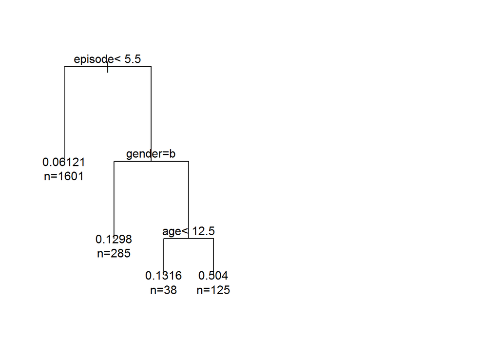

```r
library("rpart")
part <- rpart(value ~ age + gender + episode,
              data = subset(sub_long,
                            variable == "risk_sexually_reactive"))
par(mfrow = c(1,2), xpd = NA) # This is a bit of a technical addition that keeps the display from getting cut off
plot(part)
text(part, use.n = TRUE)
```

# Data Visualization

## Graph

These graphs are made using the popular and lovely `ggplot2` package. (“`gg`”" stands for “grammar of graphics”. The “`2`” stands, I believe, for the sequel.)

Any simple [Google Images search for “`ggplot2`”](https://www.google.com/search?site=&tbm=isch&source=hp&biw=1600&bih=721&q=ggplot2&oq=ggplot2&gs_l=img.3..0l10.698.1660.0.2396.7.5.0.2.2.0.73.335.5.5.0....0...1ac.1.64.img..0.7.340.4HjfTv9aYxE) will turn up some lovely and diverse plots made using `ggplot2`. Most resulting pages will also offer code samples that you can adapt to create your own versions. For additional inspiration, check out [The R Graph Gallery](https://www.r-graph-gallery.com/) or [Plotly](https://plot.ly/)’s [R Library](https://plot.ly/r/).

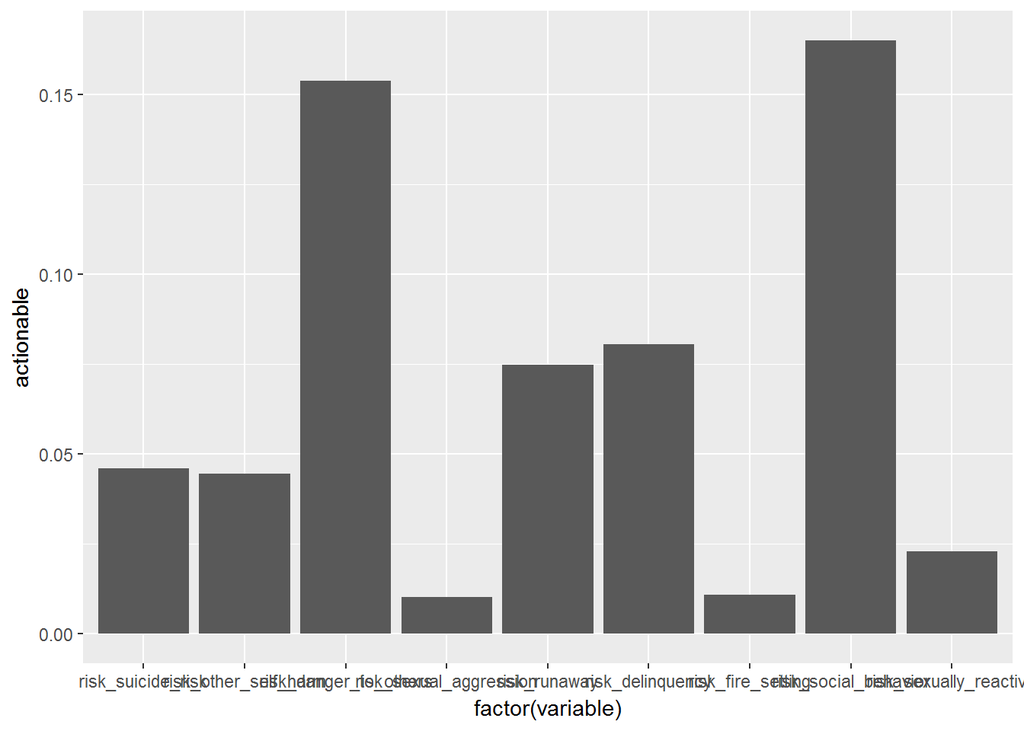

```r
library(ggplot2)
ggplot(data = avgAct_byItem, aes(x = factor(variable), y = actionable)) +
  geom_bar(stat = "identity")
```

And using several options to dress this up:

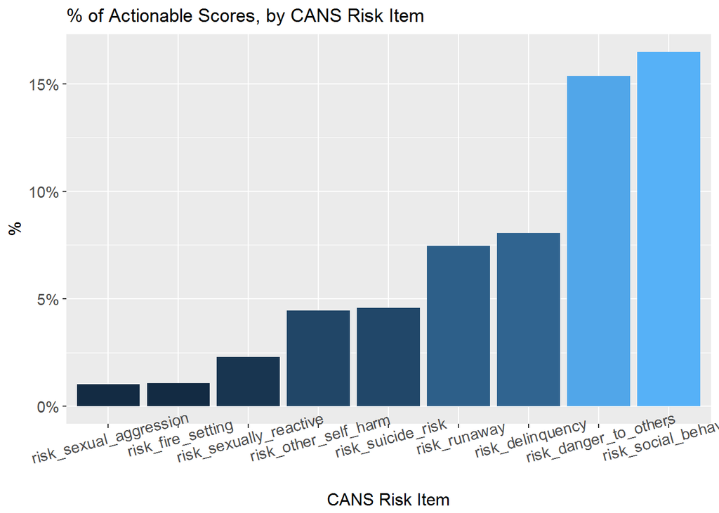

```r
# The scales package gives us percentage formatting for our axis
library(scales)

# This command reorders the values of "variable" to
# (It's admittedly a bit technical)
avgAct_byItem$variable <- factor(avgAct_byItem$variable,
                                 levels = avgAct_byItem$variable[order(avgAct_byItem$actionable)])

# Set plot code
ggplot(data = avgAct_byItem, aes(x = variable, y = actionable, fill = actionable)) +
  geom_bar(stat = "identity") +
  xlab("CANS Risk Item") + ylab("%") +
  ggtitle("% of Actionable Scores, by CANS Risk Item") +
  scale_y_continuous(labels = percent) +
  theme(legend.position = "none",
        axis.text.x = element_text(angle = 15),
        axis.text = element_text(size = 11),
        axis.title = element_text(size = 12))
```

If you find it intimidating to have to come up with the names for all of these options:

- Remember that there’s always Google! Personally, I just used Google to get the angle of the axis text set. A search for “r ggplot legend text angle” got me [this helpful page](http://docs.ggplot2.org/current/theme.html) with many specific examples. (1) Copy, (2) Paste, (3) Modify!
- Some R users out there created a (free, of course) tool called [`ggedit`](https://www.r-statistics.com/2016/11/ggedit-interactive-ggplot-aesthetic-and-theme-editor/) which lets you edit plots helps you manually select options to get all of the little aesthetics right

Using effectively the same code as above, but where we (1) use `fill = gender` instead of `fill = actionable`; and (2) use `position = "dodge"` to tell `ggplot` to put the bars side-by-side instead of stacked.

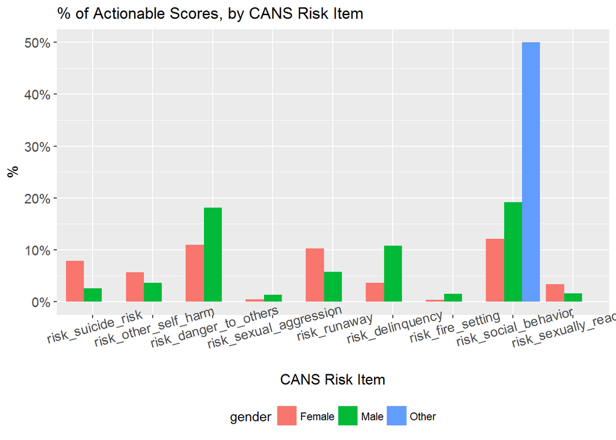

```r
# Set plot code
ggplot(data = avgAct_byItemAndGender, aes(x = variable, y = actionable, fill = gender)) +
  geom_bar(stat = "identity", position = "dodge") +
  xlab("CANS Risk Item") + ylab("%") +
  ggtitle("% of Actionable Scores, by CANS Risk Item") +
  scale_y_continuous(labels = percent) +
  theme(legend.position = "bottom",
        axis.text.x = element_text(angle = 15),
        axis.text = element_text(size = 11),
        axis.title = element_text(size = 12))
```

## Map

Because we don’t have spatial information in our data set, here’s a simple map of where it all happened!

```r
library("leaflet")
leaflet() %>%
  addTiles() %>%  # Add default OpenStreetMap map tiles
  addMarkers(lng=-74.61176991462708, lat=40.355546291270215, popup="TCOM 2016, with all the <a href = https://www.regonline.com/custImages/410000/411837/TCOM_2016AGENDAFINAL10-5-16AJ.pdf>awesome biz!</a>")
```

[interactive chart not shown]

# Disseminate

This document–well, specifically the .Rmd file that generated this output file–can produce either pdf, Word, or html files depending on what `output` option is selected at the top. (If you’re seeing this live, Nick will demonstrate.)

This document can also be used to create a batch of reports, by using another piece of code to feed data (and other instructions, if desired) into this. [Here are](http://yihui.name/knitr/demo/stitch/) some functions, thoughts, and examples for that.

R also can be used to create web applications with the [shiny](http://shiny.rstudio.com/) package. Here’s an [example of a dashboard](https://nsmader.shinyapps.io/school-day-crime-chi/) that I created to visualize crime around Chicago Public Schools by time of day. Check out the [shiny gallery](http://shiny.rstudio.com/gallery/) for inspiration, and a sense of diversity of the things that can be created. In particular, [this one](http://shiny.rstudio.com/gallery/kmeans-example.html) is one of my favorites, showing how little code–the equivalent of two short e-mails–is needed to make something very cool!